# Machine Learning Final

Rodney Harnanan

3/9/2020

## Background

### Using devices such as Jawbone Up, Nike FuelBand, and Fitbit it is now possible to collect a

### large amount of data about personal activity relatively inexpensively. These type of devices

### are part of the quantified self movement – a group of enthusiasts who take measurements about

### themselves regularly to improve their health, to find patterns in their behavior, or because

### they are tech geeks. One thing that people regularly do is quantify how much of a particular

### activity they do, but they rarely quantify how well they do it. In this project, your goal

### will be to use data from accelerometers on the belt, forearm, arm, and dumbell of 6 participants.

### They were asked to perform barbell lifts correctly and incorrectly in 5 different ways.

### More information is available from the website here:

### http://web.archive.org/web/20161224072740/http:/groupware.les.inf.puc-rio.br/har (see the section on the Weight Lifting Exercise Dataset).

## Data

### The training data for this project are available here:

### https://d396qusza40orc.cloudfront.net/predmachlearn/pml-training.csv

### The test data are available here:

### https://d396qusza40orc.cloudfront.net/predmachlearn/pml-testing.csv

### The data for this project come from this source:

### http://web.archive.org/web/20161224072740/http:/groupware.les.inf.puc-rio.br/har. If you use the document you create for this class for any purpose please cite them as they have been very generous in allowing their data to be used for this kind of assignment.

## Reproducibility

### In order to reproduce the results below, the same seed should be used.

### The Packages and Libraries below should also be installed in order to reproduce the results.

## How the model was built

### Our outcome variable is classe, a factor variable with 5 levels.

### For this data set, “participants were asked to perform one set of 10

### repetitions of the Unilateral Dumbbell Biceps Curl in 5 different fashions:

#### - exactly according to the specification (Class A)

#### - throwing the elbows to the front (Class B)

#### - lifting the dumbbell only halfway (Class C)

#### - lowering the dumbbell only halfway (Class D)

#### - throwing the hips to the front (Class E)

## Install Packages and Libraries

```r
# install.packages("caret"); install.packages("randomForest"); install.packages("rpart");
library(ggplot2);library(lattice);  library(caret); library(randomForest); library(rpart); library(rpart.plot);
set.seed(1321)
```

### Some missing values are coded as string “#DIV/0!” or "" or “NA” - these will be changed to NA.

```r
trainUrl <- "http://d396qusza40orc.cloudfront.net/predmachlearn/pml-training.csv"

testUrl <- "http://d396qusza40orc.cloudfront.net/predmachlearn/pml-testing.csv"
```

## Load

```r
training <- read.csv(url(trainUrl), na.strings=c("NA","#DIV/0!",""))
testing <- read.csv(url(testUrl), na.strings=c("NA","#DIV/0!",""))
```

### Check dimensions for number of variables and number of observations

```r
dim(training)
```

```
## [1] 19622   160
```

```r
dim(testing)
```

```
## [1]  20 160
```

```r
training<-training[,colSums(is.na(training)) == 0]
testing <-testing[,colSums(is.na(testing)) == 0]
```

### Check dimensions for number of variables after missing values are removed

```r
dim(training)
```

```
## [1] 19622    60
```

```r
dim(testing)
```

```
## [1] 20 60
```

### Some variables are irrelevant to our current project: user_name, raw_timestamp_part_1,

### raw_timestamp_part_,2 cvtd_timestamp, new_window, and num_window (columns 1 to 7).

### We can delete these variables.

```r
training   <-training[,-c(1:7)]

testing <-testing[,-c(1:7)]
```

### Check dimensions and str

```r
dim(training)
```

```
## [1] 19622    53
```

```r
dim(testing)
```

```
## [1] 20 53
```

```r
str(training)
```

```
## 'data.frame':    19622 obs. of  53 variables:
##  $ roll_belt           : num  1.41 1.41 1.42 1.48 1.48 1.45 1.42 1.42 1.43 1.45 ...
##  $ pitch_belt          : num  8.07 8.07 8.07 8.05 8.07 8.06 8.09 8.13 8.16 8.17 ...
##  $ yaw_belt            : num  -94.4 -94.4 -94.4 -94.4 -94.4 -94.4 -94.4 -94.4 -94.4 -94.4 ...
##  $ total_accel_belt    : int  3 3 3 3 3 3 3 3 3 3 ...
##  $ gyros_belt_x        : num  0 0.02 0 0.02 0.02 0.02 0.02 0.02 0.02 0.03 ...
##  $ gyros_belt_y        : num  0 0 0 0 0.02 0 0 0 0 0 ...
##  $ gyros_belt_z        : num  -0.02 -0.02 -0.02 -0.03 -0.02 -0.02 -0.02 -0.02 -0.02 0 ...
##  $ accel_belt_x        : int  -21 -22 -20 -22 -21 -21 -22 -22 -20 -21 ...
##  $ accel_belt_y        : int  4 4 5 3 2 4 3 4 2 4 ...
##  $ accel_belt_z        : int  22 22 23 21 24 21 21 21 24 22 ...
##  $ magnet_belt_x       : int  -3 -7 -2 -6 -6 0 -4 -2 1 -3 ...
##  $ magnet_belt_y       : int  599 608 600 604 600 603 599 603 602 609 ...
##  $ magnet_belt_z       : int  -313 -311 -305 -310 -302 -312 -311 -313 -312 -308 ...
##  $ roll_arm            : num  -128 -128 -128 -128 -128 -128 -128 -128 -128 -128 ...
```

[output cut: 39 more lines]

```r
str(testing)
```

```
## 'data.frame':    20 obs. of  53 variables:
##  $ roll_belt           : num  123 1.02 0.87 125 1.35 -5.92 1.2 0.43 0.93 114 ...
##  $ pitch_belt          : num  27 4.87 1.82 -41.6 3.33 1.59 4.44 4.15 6.72 22.4 ...
##  $ yaw_belt            : num  -4.75 -88.9 -88.5 162 -88.6 -87.7 -87.3 -88.5 -93.7 -13.1 ...
##  $ total_accel_belt    : int  20 4 5 17 3 4 4 4 4 18 ...
##  $ gyros_belt_x        : num  -0.5 -0.06 0.05 0.11 0.03 0.1 -0.06 -0.18 0.1 0.14 ...
##  $ gyros_belt_y        : num  -0.02 -0.02 0.02 0.11 0.02 0.05 0 -0.02 0 0.11 ...
##  $ gyros_belt_z        : num  -0.46 -0.07 0.03 -0.16 0 -0.13 0 -0.03 -0.02 -0.16 ...
##  $ accel_belt_x        : int  -38 -13 1 46 -8 -11 -14 -10 -15 -25 ...
##  $ accel_belt_y        : int  69 11 -1 45 4 -16 2 -2 1 63 ...
##  $ accel_belt_z        : int  -179 39 49 -156 27 38 35 42 32 -158 ...
##  $ magnet_belt_x       : int  -13 43 29 169 33 31 50 39 -6 10 ...
##  $ magnet_belt_y       : int  581 636 631 608 566 638 622 635 600 601 ...
##  $ magnet_belt_z       : int  -382 -309 -312 -304 -418 -291 -315 -305 -302 -330 ...
##  $ roll_arm            : num  40.7 0 0 -109 76.1 0 0 0 -137 -82.4 ...
```

[output cut: 39 more lines]

### The training data set is partionned into 2 sets: subTraining (70%) and subTest (30%).

### This will be performed using random subsampling without replacement.

```r
subsamples <- createDataPartition(y=training$classe, p=0.70, list=FALSE)
subTraining <- training[subsamples, ]
subTesting <- training[-subsamples, ]
dim(subTraining)
```

```
## [1] 13737    53
```

```r
dim(subTesting)
```

```
## [1] 5885   53
```

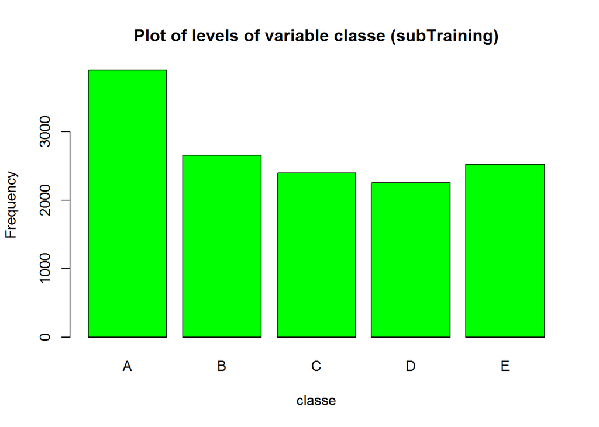

```r
plot(subTraining$classe, col="green", main="Plot of levels of variable classe (subTraining)", xlab="classe", ylab="Frequency")
```

### Level A is most frequent and level D is the least.

## Training Decision Tree

```r
modelDtree <- rpart(classe ~ ., data=subTraining, method="class")
```

## Predicting

```r
prediction1 <- predict(modelDtree, subTesting, type = "class")
```

## Plot the Decision Tree

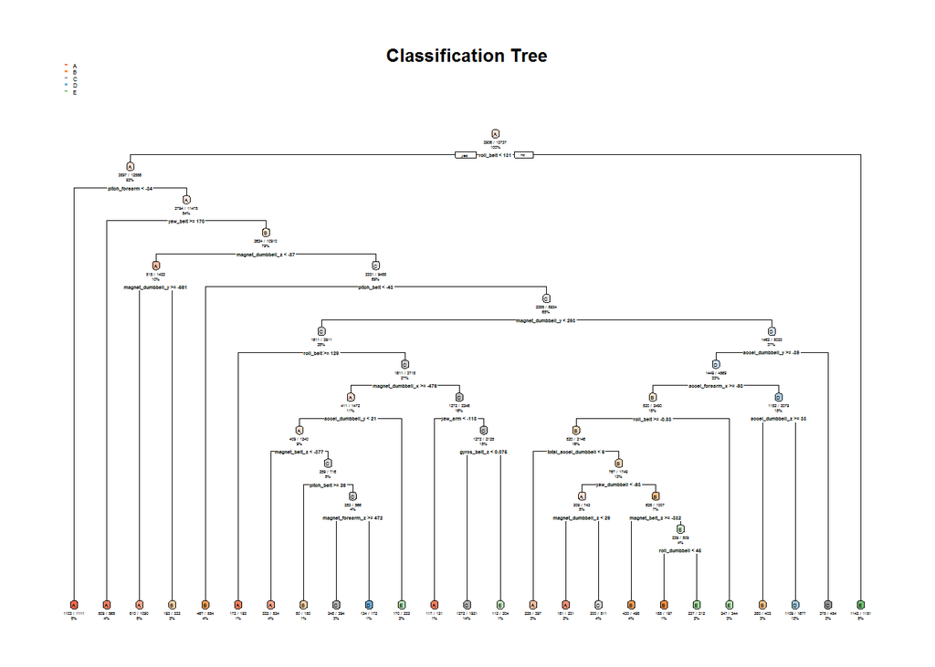

```r
rpart.plot(modelDtree, main="Classification Tree", extra=102, under=TRUE, faclen=0)
```

### Test results on our subTesting data set:

```r
confusionMatrix(prediction1, subTesting$classe)
```

```
## Confusion Matrix and Statistics
##
##           Reference
## Prediction    A    B    C    D    E
##          A 1471  204   28   92   37
##          B   44  694   71   60   57
##          C   27  160  893  207  135
##          D  111   72   27  486   46
##          E   21    9    7  119  807
##
## Overall Statistics
##
##                Accuracy : 0.7393
##                  95% CI : (0.7279, 0.7505)
##     No Information Rate : 0.2845
##     P-Value [Acc > NIR] : < 2.2e-16
##
##                   Kappa : 0.6693
##
##  Mcnemar's Test P-Value : < 2.2e-16
##
## Statistics by Class:
##
##                      Class: A Class: B Class: C Class: D Class: E
## Sensitivity            0.8787   0.6093   0.8704  0.50415   0.7458
## Specificity            0.9143   0.9511   0.8911  0.94798   0.9675
## Pos Pred Value         0.8029   0.7495   0.6280  0.65499   0.8380
## Neg Pred Value         0.9499   0.9103   0.9702  0.90706   0.9441
## Prevalence             0.2845   0.1935   0.1743  0.16381   0.1839
## Detection Rate         0.2500   0.1179   0.1517  0.08258   0.1371
## Detection Prevalence   0.3113   0.1573   0.2416  0.12608   0.1636
## Balanced Accuracy      0.8965   0.7802   0.8808  0.72606   0.8567
```

## Training Random Forest

```r
modelRF <- randomForest(classe ~. , data=subTraining, method="class")
```

## Predicting:

```r
prediction2 <- predict(modelRF, subTesting, type = "class")
```

# Test results on subTesting data set:

```r
confusionMatrix(prediction2, subTesting$classe)
```

```
## Confusion Matrix and Statistics
##
##           Reference
## Prediction    A    B    C    D    E
##          A 1674    3    0    0    0
##          B    0 1133    4    0    0
##          C    0    3 1021   19    0
##          D    0    0    1  944    4
##          E    0    0    0    1 1078
##
## Overall Statistics
##
##                Accuracy : 0.9941
##                  95% CI : (0.9917, 0.9959)
##     No Information Rate : 0.2845
##     P-Value [Acc > NIR] : < 2.2e-16
##
##                   Kappa : 0.9925
##
##  Mcnemar's Test P-Value : NA
##
## Statistics by Class:
##
##                      Class: A Class: B Class: C Class: D Class: E
## Sensitivity            1.0000   0.9947   0.9951   0.9793   0.9963
## Specificity            0.9993   0.9992   0.9955   0.9990   0.9998
## Pos Pred Value         0.9982   0.9965   0.9789   0.9947   0.9991
## Neg Pred Value         1.0000   0.9987   0.9990   0.9959   0.9992
## Prevalence             0.2845   0.1935   0.1743   0.1638   0.1839
## Detection Rate         0.2845   0.1925   0.1735   0.1604   0.1832
## Detection Prevalence   0.2850   0.1932   0.1772   0.1613   0.1833
## Balanced Accuracy      0.9996   0.9969   0.9953   0.9891   0.9980
```

## predict levels on the original testing data, using Random Forest.

```r
predictfinal <- predict(modelRF, testing, type="class")

predictfinal
```

```
##  1  2  3  4  5  6  7  8  9 10 11 12 13 14 15 16 17 18 19 20
##  B  A  B  A  A  E  D  B  A  A  B  C  B  A  E  E  A  B  B  B
## Levels: A B C D E
```

### [1] Velloso, E.; Bulling, A.; Gellersen, H.; Ugulino, W.; Fuks, H. Qualitative Activity Recognition of Weight Lifting Exercises.

###Proceedings of 4th International Conference in Cooperation with SIGCHI (Augmented Human ’13) . Stuttgart, Germany: ACM SIGCHI, 2013.

### [2] Krzysztof Gra??bczewski and Norbert Jankowski. Feature Selection with Decision Tree Criterion.